# Mathematical Modeling Assignment 3

Alyssa Obermayer

10/3/2020

## **Question 1**

## *Part A*

Part A of question one takes the Leslie matrix provided to find the stable growth rate of the population of sea turtles presented. To find this growth rate, I generated a matrix and found the eigenvalues and vectors, then took the absolute value of the largest eigenvalue that RStudio computed, which is shown below as R.

```r
#Generating the Leslie Matrix
A <- matrix(c(0,0.675,0,0,0,0,0.703,0.047,0,0,0,0,0.657,0.019,0,4.665,0,0,0.682,0.061,61.896,0,0,0,0.8091), nrow = 5, ncol = 5)

#Find the eigenvalue and vector of the matrix (A)
EVs <- eigen(A)

#Assign largest eigenvalue to big R (Geometric Growth Factor>Stable population growth rate)
R <- abs(eigen(A)$values[1])
R
```

```
## [1] 0.9515817
```

## *Part B*

For Part B of question 1 we want to adjust two different parameters separately to see their affect on growth rate of the sea turtle population.

The first parameter we are adjusting is increasing the survival rate of the juvenile sea turtles to 100%. To do this I took the P value located in the original matrix, 0.675and adjusted it to be 1.000. This signifies that there is a 100% probability that the juvenile sea turtles will grow to the second stage of their life.

```r
#Juvenile Change
#Generate Leslie Matrix with increased survival of juvenile stage to 100%
AJ <- matrix(c(0, 1.000,0,0,0,0,0.703,0.047,0,0,0,0,0.657,0.019,0,4.665,0,0,0.682,0.061,61.896,0,0,0,0.8091),
             nrow = 5, ncol = 5)

#Find the eigenvalue and vector of the matrix (AJ)
EVsJ <- eigen(AJ)

#Assign largest eigenvalue to big R (Geometric Growth Factor>Stable population growth rate)
RJ <- abs(eigen(AJ)$values[1])
RJ
```

```
## [1] 0.9744496
```

```r
#Clutch size change
#Decrease clutch size for large mature size class by half
MCS <- (A[1,5]/2)

#Generate Leslie Matrix with large mature size class by half
AC <- matrix(c(0, 0.675,0,0,0,0,0.703,0.047,0,0,0,0,0.657,0.019,0,4.665,0,0,0.682,0.061,30.948,0,0,0,0.8091),
             nrow = 5, ncol = 5)

#Find the eigenvalue and vector of the matrix (AC)
EVsC <- eigen(AC)

#Assign largest eigenvalue to big R (Geometric Growth Factor>Stable population growth rate)
RC <- abs(eigen(AC)$values[1])
RC
```

```
## [1] 0.9221861
```

```r
#Find change in new R values from original
ChangeWithRJ <- eval(abs(R-RJ))
ChangeWithRJ
```

```
## [1] 0.02286786
```

```r
ChangeWithRC <- eval(abs(R-RC))
ChangeWithRC
```

```
## [1] 0.0293956
```

## *Part C*

```r
#While loop to find where the largest eigenvalue exceeds 1
AcM <- matrix(c(0,0.675,0,0,0,0,0.703,0.047,0,0,0,0,0.657,0.019,0,4.665,0,0,0.682,0.061,61.896,0,0,0,0.8091), nrow = 5, ncol = 5)
while (abs(eigen(AcM)$values[1]) < 1) {
  AcM[4,4] = (AcM[4,4] + 0.01)
  AcM[5,5] = (AcM[5,5] + 0.01)
}

#Find largest eigenvalue and view new (R>1) matrix
AcMeigen <- eigen(AcM)$values[1]
AcMeigen
```

```
## [1] 1.004368+0i
```

```r
print(AcM)
```

```
##       [,1]  [,2]  [,3]  [,4]    [,5]
## [1,] 0.000 0.000 0.000 4.665 61.8960
## [2,] 0.675 0.703 0.000 0.000  0.0000
## [3,] 0.000 0.047 0.657 0.000  0.0000
## [4,] 0.000 0.000 0.019 0.772  0.0000
## [5,] 0.000 0.000 0.000 0.061  0.8991
```

```r
#Find difference between probability of survival in stages 4 & 5 of the original matrix and new (R>1) matrix
diff44 <- abs(A[4,4]-AcM[4,4])
diff55 <- abs(A[5,5]-AcM[5,5])
print(c(diff44, diff55))
```

```
## [1] 0.09 0.09
```

## *Part D*

```r
pMat <- AcM               #Projection matrix to be used
pYears <- 50              #Number of years we are projecting over
n0 <- c(300,800,50,50,50) #Define initial population

StorYears <- matrix(0, nrow = nrow(pMat), ncol = (pYears + 1)) #Storage array for abundances
StorYears[,1] <- n0                                            #Setting initial abundance at year zero
for (t in 2:(pYears + 1)) {                                    #Create loop to project 50 years
  StorYears[,t] <- pMat %*% StorYears[,t-1]                    #Multiplies the projection matrix by the previous years population size
}

StorYears
```

```
##      [,1]     [,2]       [,3]       [,4]       [,5]       [,6]       [,7]
## [1,]  300 3328.050 3155.81823 2969.51766 2778.61972 2597.92687 2439.06464
## [2,]  800  764.900 2784.15845 4087.44070 4877.89523 5304.72865 5482.82488
## [3,]   50   70.450   82.23595  184.88447  313.57881  435.28235  535.30275
## [4,]   50   39.550   31.87115   26.16701   23.71374   24.26500   27.00295
## [5,]   50   48.005   45.57385   42.91958   40.18519   37.57704   35.26568
##            [,8]       [,9]      [,10]      [,11]      [,12]      [,13]
## [1,] 2308.77333 2209.20787 2139.03074 2094.66637 2071.41534 2064.31128
## [2,] 5500.79452 5425.48054 5305.32813 5173.49143 5050.86428 4948.96294
## [3,]  609.38668  658.90439  687.89777  701.29926  703.90771  699.85799
## [4,]   31.01703   35.52349   39.94332   43.90630   47.22035   49.82836
## [5,]   33.35455   31.88112   30.83125   30.15692   29.79237   29.66676
##           [,14]      [,15]      [,16]      [,17]      [,18]      [,19]
## [1,] 2068.70297 2080.59318 2096.78650 2114.90111 2133.29438 2150.94234
## [2,] 4872.53106 4821.76384 4794.10038 4785.58345 4791.82342 4808.62557
```

[output cut: 39 more lines]

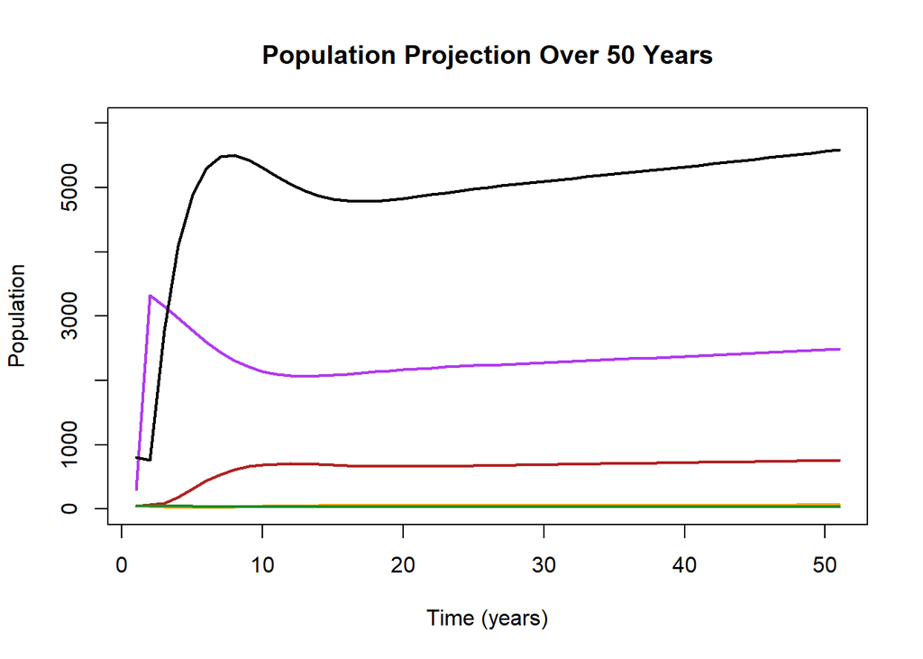

```r
#Plot population projection over 50 years
plot(StorYears[1,], ylim = c(0, 6000), type = "l", lwd = 2, ylab = "Population", xlab = "Time (years)", main = "Population Projection Over 50 Years", col = "darkorchid2")
lines(StorYears[2,], lwd = 2, ylab = "Population", xlab = "Time (years)", main = "Population Projection Over 50 Years", col = "black")
lines(StorYears[3,], lwd = 2, ylab = "Population", xlab = "Time (years)", main = "Population Projection Over 50 Years", col = "firebrick")
lines(StorYears[4,], lwd = 2, ylab = "Population", xlab = "Time (years)", main = "Population Projection Over 50 Years", col = "orange")
lines(StorYears[5,], lwd = 2, ylab = "Population", xlab = "Time (years)", main = "Population Projection Over 50 Years", col = "forestgreen")
```

```r
#Compare found numbers to "PopBio" R package
library(popbio)
pop.projection(AcM, c(300,800,50,50,50), 51)
```

```
## $lambda
## [1] 1.004369
##
## $stable.stage
## [1] 0.279176206 0.625293498 0.084603754 0.006917820 0.004008721
##
## $stage.vectors
##        0        1          2          3          4          5          6
## [1,] 300 3328.050 3155.81823 2969.51766 2778.61972 2597.92687 2439.06464
## [2,] 800  764.900 2784.15845 4087.44070 4877.89523 5304.72865 5482.82488
## [3,]  50   70.450   82.23595  184.88447  313.57881  435.28235  535.30275
## [4,]  50   39.550   31.87115   26.16701   23.71374   24.26500   27.00295
## [5,]  50   48.005   45.57385   42.91958   40.18519   37.57704   35.26568
##               7          8          9         10         11         12
## [1,] 2308.77333 2209.20787 2139.03074 2094.66637 2071.41534 2064.31128
```

[output cut: 65 more lines]

## **Question 2**

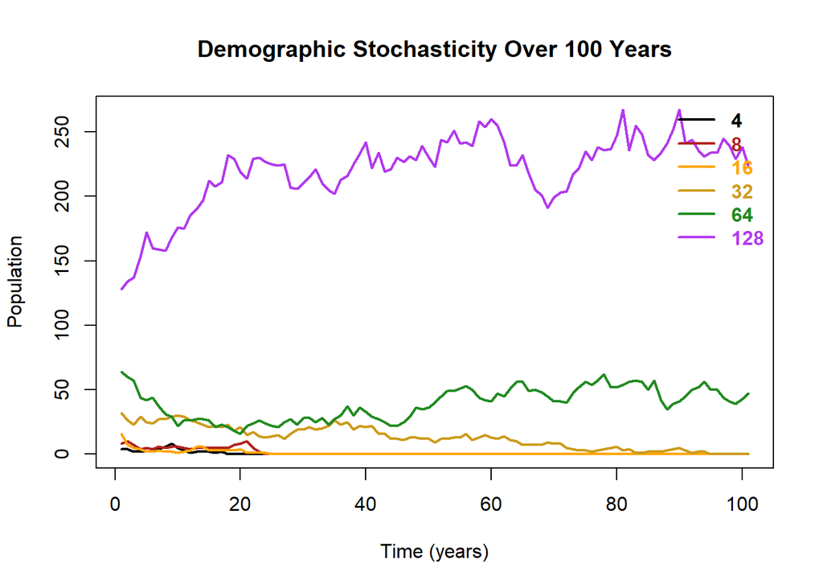

```r
#Demographic Stochasticity Function
demogstoch <- function(p0,p1,n0,times) {
  n = n0
  for (i in 1:times) {
    new_n = 0
    if (n[i] == 0) {
      n <- c(n, new_n) #Makes sure population cannot grow from zero
    } else {
      for (j in 1:n[i]) {
        luck = runif(1)
        if (luck < p0) {
          new_n = new_n
        } else {
          if (luck < p0 + p1) {
            new_n = new_n + 1
          } else {
            new_n = new_n + 2}
        }
      }
      n <- c(n, new_n)
    }
  }
  return(n)
}

#Run function for different starting population
n0.4 <- demogstoch(0.25,0.5,4,100)
n0.8 <- demogstoch(0.25,0.5,8,100)
n0.16 <- demogstoch(0.25,0.5,16,100)
n0.32 <- demogstoch(0.25,0.5,32,100)
n0.64 <- demogstoch(0.25,0.5,64,100)
n0.128 <- demogstoch(0.25,0.5,128,100)

#Plot all models
plot(n0.128,ylim = c(0,max(n0.128)),type = "l",ylab = "Population",xlab = "Time (years)",main = "Demographic Stochasticity Over 100 Years",
     lwd = 2,col = "darkorchid2")
lines(n0.4,ylab = "Population",xlab = "Time (years)",lwd = 2,col = "black")
lines(n0.8,ylab = "Population",xlab = "Time (years)",lwd = 2,col = "firebrick")
lines(n0.16,ylab = "Population",xlab = "Time (years)",lwd = 2,col = "orange")
lines(n0.32,ylab = "Population",xlab = "Time (years)",lwd = 2,col = "goldenrod3")
lines(n0.64,ylab = "Population",xlab = "Time (years)",lwd = 2,col = "forestgreen")
legend("topright",legend=c("4","8","16","32","64","128"),
       text.col = c("black","firebrick","orange","goldenrod3","forestgreen","darkorchid2"),
       lty = 1,col = c("black","firebrick","orange","goldenrod3","forestgreen","darkorchid2"),
       box.lty = 0,lwd = 2, bg = "transparent", text.font = 2)
```

```r
#Generate data frames to see exact numerical variation from the graph
n0.4df <- data.frame(n0.4)
n0.8df <- data.frame(n0.8)
n0.16df <- data.frame(n0.16)
n0.32df <- data.frame(n0.32)
n0.64df <- data.frame(n0.64)
n0.128df <- data.frame(n0.128)
```

## **Question 3**

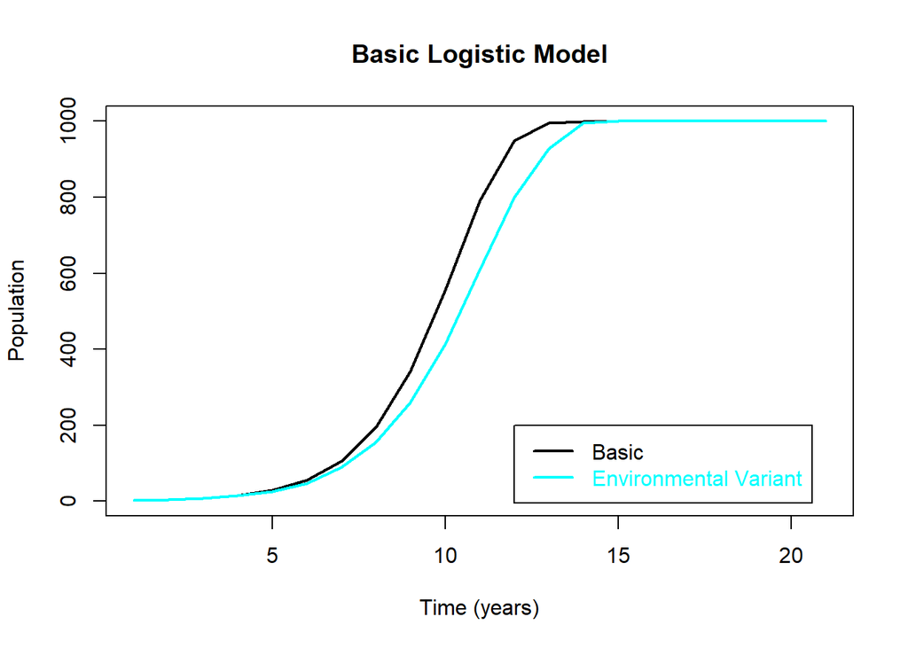

```r
#Logistic Model with Environmental Variation

#Logistic Model with Environmental Variation Function
logistic <- function(rbad, rgood, rneut, k, n0, time){
  n <- n0
    for (t in 1:time){
      if (runif(1) < 0.33) { #Random switch between bad, neutral, and good conditions
        r = rbad
      } else {
        if (0.33 > runif(1) && runif(1) < 0.66) {
          r = rneut
        } else {
          if (runif(1) > 0.66) {
            r = rgood
          }
        }
      }
      nprime <- n[t] + r*n[t]*(k-n[t])/k
      if (nprime < 0) nprime = 0
      n <- c(n, nprime) #Ensures the population cannot bounce back from zero
    }
  return(n)
}

#Logistic Model with Environmental Variation Function Values
envrlog <- logistic((4/5),(5/4),1,1000,2,20)

#Basic Logistic Model

#Basic Logistic Model Function
logistic <- function(r, k, n0, time){
  n <- n0
    for (t in 1:time){
      nprime <- n[t] + r*n[t]*(k-n[t])/k
      if (nprime < 0) nprime = 0 #Ensures the population cannot bounce back from zero
      n <- c(n, nprime)
    }
  return(n)
}

#Basic Logistic Model Function Values
logR <- logistic(R,1000,2,20)

#Plotting Basic Logistics Model with and without Environmental Variation
plot(logR,
     type = "l",
     lwd = 2,
     ylab = "Population",
     xlab = "Time (years)",
     main = "Basic Logistic Model")
lines(envrlog,
     type = "l",
     lwd = 2,
     ylab = "Population",
     xlab = "Time (years)",
     main = "Logistic Model with Environmental Variation",
     col = "cyan")
legend(12, 200,
       legend = c("Basic","Environmental Variant"),
       text.col = c("black","cyan"),
       lty = 1,
       lwd = 2,
       col = c("black","cyan"))
```